# Farnham Food Hygiene Ratings

Data Profiling

Clare Gibson

# Introduction

This script outlines the steps take to profile the data from the Food Hygiene Ratings dataset. This script will not make any edits to the data but will note down where cleaning actions should be taken so that this can be performed with an R script in the overall pipeline.

# Packages

Load the packages to be used for this project.

```r
library(here)
library(knitr)
library(sf)
library(mapview)
```

# Load the data

The data for profiling is contained in the `fhr_data` object created in the `2-prep-data.R` script.

| fhrsid | local_authority_business_id | business_name | business_type | business_type_id | rating_value | rating_key | rating_date | local_authority_code | local_authority_name | local_authority_web_site | local_authority_email_address | hygiene | structural | confidence_in_management | scheme_type | new_rating_pending | longitude | latitude | address_line1 | address_line2 | address_line3 | address_line4 | post_code | fhrs_establishment_id |
| --- | --- | --- | --- | --- | --- | --- | --- | --- | --- | --- | --- | --- | --- | --- | --- | --- | --- | --- | --- | --- | --- | --- | --- | --- |
| 1199283 | PI/000134037 | 3D Spice | Other catering premises | 7841 | 5 | fhrs_5_en-GB | 2022-02-01 | 314 | Waverley | http://www.waverley.gov.uk | environmentalhealth@waverley.gov.uk | 0 | 0 | 0 | FHRS | FALSE | NA | NA | NA | NA | NA | NA | NA | EstablishmentDetail |
| 177971 | PI/000044599 | 40 Degreez | Other catering premises | 7841 | 5 | fhrs_5_en-GB | 2022-05-27 | 314 | Waverley | http://www.waverley.gov.uk | environmentalhealth@waverley.gov.uk | 5 | 5 | 5 | FHRS | FALSE | -0.793374 | 51.21678 | Farnham Youth Project | Dogflud Way | Farnham | Surrey | NA | EstablishmentDetail |
| 1495850 | PI/000180590 | 7AM Premier Farnham | Retailers - other | 4613 | 1 | fhrs_1_en-GB | 2022-12-08 | 314 | Waverley | http://www.waverley.gov.uk | environmentalhealth@waverley.gov.uk | 15 | 15 | 20 | FHRS | FALSE | -0.762408 | 51.23089 | 57-59 Badshot Lea Road | Badshot Lea | Farnham | Surrey | GU9 9LP | EstablishmentDetail |
| 1209035 | PI/000178110 | A & R Convenience Store | Retailers - other | 4613 | 5 | fhrs_5_en-GB | 2023-02-01 | 314 | Waverley | http://www.waverley.gov.uk | environmentalhealth@waverley.gov.uk | 5 | 5 | 0 | FHRS | FALSE | -0.606548 | 51.19057 | 7 Meadrow | Godalming | Surrey | NA | GU7 3HJ | EstablishmentDetail |
| 1531219 | PI/000161558 | A Bite to Wheat | Other catering premises | 7841 | 5 | fhrs_5_en-GB | 2022-06-09 | 314 | Waverley | http://www.waverley.gov.uk | environmentalhealth@waverley.gov.uk | 0 | 0 | 0 | FHRS | FALSE | NA | NA | NA | NA | NA | NA | NA | EstablishmentDetail |
| 1495839 | PI/000124651 | A Fancy Piece | Other catering premises | 7841 | 5 | fhrs_5_en-GB | 2022-03-15 | 314 | Waverley | http://www.waverley.gov.uk | environmentalhealth@waverley.gov.uk | 5 | 5 | 0 | FHRS | FALSE | NA | NA | NA | NA | NA | NA | NA | EstablishmentDetail |

# Dataframe profile

The dataframe has 982 rows and 25 columns. A `glimpse` of the data is shown below.

```
## Rows: 982
## Columns: 25
## $ fhrsid                        <dbl> 1199283, 177971, 1495850, 1209035, 15312…
## $ local_authority_business_id   <chr> "PI/000134037", "PI/000044599", "PI/0001…
## $ business_name                 <chr> "3D Spice", "40 Degreez", "7AM Premier F…
## $ business_type                 <chr> "Other catering premises", "Other cateri…
## $ business_type_id              <dbl> 7841, 7841, 4613, 4613, 7841, 7841, 7841…
## $ rating_value                  <chr> "5", "5", "1", "5", "5", "5", "5", "0", …
## $ rating_key                    <chr> "fhrs_5_en-GB", "fhrs_5_en-GB", "fhrs_1_…
## $ rating_date                   <date> 2022-02-01, 2022-05-27, 2022-12-08, 202…
## $ local_authority_code          <dbl> 314, 314, 314, 314, 314, 314, 314, 314, …
## $ local_authority_name          <chr> "Waverley", "Waverley", "Waverley", "Wav…
## $ local_authority_web_site      <chr> "http://www.waverley.gov.uk", "http://ww…
## $ local_authority_email_address <chr> "environmentalhealth@waverley.gov.uk", "…
## $ hygiene                       <dbl> 0, 5, 15, 5, 0, 5, 5, 15, 5, 0, 5, 0, 0,…
## $ structural                    <dbl> 0, 5, 15, 5, 0, 5, 0, 20, 5, 0, 0, 5, 5,…
## $ confidence_in_management      <dbl> 0, 5, 20, 0, 0, 0, 0, 20, 5, 0, 5, 10, 5…
## $ scheme_type                   <chr> "FHRS", "FHRS", "FHRS", "FHRS", "FHRS", …
## $ new_rating_pending            <lgl> FALSE, FALSE, FALSE, FALSE, FALSE, FALSE…
## $ longitude                     <dbl> NA, -0.7933740, -0.7624080, -0.6065480, …
## $ latitude                      <dbl> NA, 51.21678, 51.23089, 51.19057, NA, NA…
## $ address_line1                 <chr> NA, "Farnham Youth Project", "57-59 Bads…
## $ address_line2                 <chr> NA, "Dogflud Way", "Badshot Lea", "Godal…
## $ address_line3                 <chr> NA, "Farnham", "Farnham", "Surrey", NA, …
## $ address_line4                 <chr> NA, "Surrey", "Surrey", NA, NA, NA, NA, …
## $ post_code                     <chr> NA, NA, "GU9 9LP", "GU7 3HJ", NA, NA, NA…
## $ fhrs_establishment_id         <chr> "EstablishmentDetail", "EstablishmentDet…
```

# Column profiling

Look at each column in turn and assess the number of unique values. Is any recoding required?

## `fhrsid`

- There are 982 unique values.
- This is an ID column with no duplicates.

## `local_authority_business_id`

- There are 982 unique values
- This is an ID column with no duplicates.

## `business_name`

- There are 939 unique values.
- Be aware there are some duplicated business names.

## `business_type`

- There are 13 unique values.

| business_type | n | prop |
| --- | --- | --- |
| Restaurant/Cafe/Canteen | 188 | 0.19 |
| Other catering premises | 179 | 0.18 |
| Retailers - other | 153 | 0.16 |
| Hospitals/Childcare/Caring Premises | 110 | 0.11 |
| Pub/bar/nightclub | 95 | 0.10 |
| School/college/university | 82 | 0.08 |
| Takeaway/sandwich shop | 52 | 0.05 |
| Mobile caterer | 50 | 0.05 |
| Manufacturers/packers | 28 | 0.03 |
| Hotel/bed & breakfast/guest house | 20 | 0.02 |
| Retailers - supermarkets/hypermarkets | 19 | 0.02 |
| Distributors/Transporters | 5 | 0.01 |
| Farmers/growers | 1 | 0.00 |

## `business_type_id`

There are 13 unique values.

| business_type_id | n | prop |
| --- | --- | --- |
| 1 | 188 | 0.19 |
| 7841 | 179 | 0.18 |
| 4613 | 153 | 0.16 |
| 5 | 110 | 0.11 |
| 7843 | 95 | 0.10 |
| 7845 | 82 | 0.08 |
| 7844 | 52 | 0.05 |
| 7846 | 50 | 0.05 |
| 7839 | 28 | 0.03 |
| 7842 | 20 | 0.02 |
| 7840 | 19 | 0.02 |
| 7 | 5 | 0.01 |
| 7838 | 1 | 0.00 |

## `rating_value`

- There are 8 unique values.

| rating_value | n | prop |
| --- | --- | --- |
| 5 | 729 | 0.74 |
| 4 | 116 | 0.12 |
| 3 | 58 | 0.06 |
| Exempt | 43 | 0.04 |
| 2 | 16 | 0.02 |
| 1 | 12 | 0.01 |
| AwaitingInspection | 7 | 0.01 |
| 0 | 1 | 0.00 |

- Note the mix of character and numeric. Could we remove character?
- Let’s also plot a histogram of the numeric values to see the distribution.

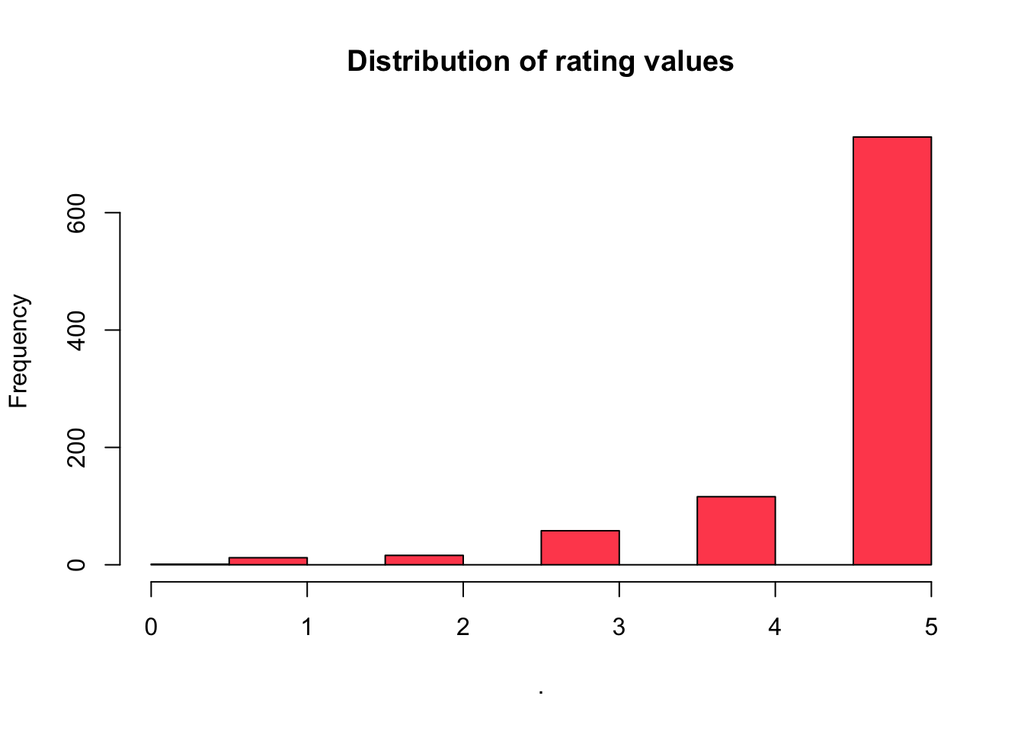

## `rating_key`

- There are 8 unique values.

| rating_key | n | prop |
| --- | --- | --- |
| fhrs_5_en-GB | 729 | 0.74 |
| fhrs_4_en-GB | 116 | 0.12 |
| fhrs_3_en-GB | 58 | 0.06 |
| fhrs_exempt_en-GB | 43 | 0.04 |
| fhrs_2_en-GB | 16 | 0.02 |
| fhrs_1_en-GB | 12 | 0.01 |
| fhrs_awaitinginspection_en-GB | 7 | 0.01 |
| fhrs_0_en-GB | 1 | 0.00 |

- This column supplements the `rating_value` column nicely. We probably don’t need to add another column.

## `rating_date`

- There are 389 unique values.
- Earliest date is 2016-01-22
- Latest date is 2023-07-19

```
##         Min.      1st Qu.       Median         Mean      3rd Qu.         Max.
## "2016-01-22" "2022-02-11" "2022-07-01" "2022-07-04" "2023-01-20" "2023-07-19"
##         NA's
##          "7"
```

## `local_authority_code`

- There is 1 unique value.
- This should be treated as metadata since the same value applies to every record.

## `local_authority_name`

- There is 1 unique value.
- This should be treated as metadata since the same value applies to every record.

## `local_authority_web_site`

- There is 1 unique value.
- This should be treated as metadata since the same value applies to every record.

## `local_authority_email_address`

- There is 1 unique value.
- This should be treated as metadata since the same value applies to every record.

## `hygiene`

- There are 5 unique values.

| hygiene | n | prop |
| --- | --- | --- |
| 0 | 587 | 0.60 |
| 5 | 241 | 0.25 |
| 10 | 94 | 0.10 |
| NA | 50 | 0.05 |
| 15 | 10 | 0.01 |

- This column is part of the `score` tag in the original xml file.

## `structural`

- There are 6 unique values.

| structural | n | prop |
| --- | --- | --- |
| 0 | 458 | 0.47 |
| 5 | 358 | 0.36 |
| 10 | 95 | 0.10 |
| NA | 50 | 0.05 |
| 15 | 20 | 0.02 |
| 20 | 1 | 0.00 |

- This column is part of the `score` tag in the original xml file.

## `confidence_in_management`

- There are 5 unique values.

| confidence_in_management | n | prop |
| --- | --- | --- |
| 0 | 506 | 0.52 |
| 5 | 311 | 0.32 |
| 10 | 102 | 0.10 |
| NA | 50 | 0.05 |
| 20 | 13 | 0.01 |

- This column is part of the `score` tag in the original xml file.

## `scheme_type`

- There is 1 unique value.
- This should be treated as metadata since the same value applies to every record.

## `new_rating_pending`

- There are 2 unique values.

| new_rating_pending | n | prop |
| --- | --- | --- |
| FALSE | 973 | 0.99 |
| TRUE | 9 | 0.01 |

## `longitude` and `latitude`

- There are 589 unique values of longitude.
- There are 592 unique values of latitude.
- Summary of `longitude`

```
##    Min. 1st Qu.  Median    Mean 3rd Qu.    Max.    NA's
## -0.8366 -0.7866 -0.7098 -0.6800 -0.6072 -0.4050     226
```

- Summary of `latitude`

```
##    Min. 1st Qu.  Median    Mean 3rd Qu.    Max.    NA's
##   51.08   51.14   51.19   51.17   51.21   51.31     226
```

- Let’s plot the points on a map to ensure they are all valid locations within Waverley.

[interactive chart not shown]

- Most of the points appear to be in Waverley Borough, which covers the towns of Farnham, Godalming, Haslemere and Cranleigh. However, there are 2 points that appear to outside of Waverley. Clicking on the points reveals more data and we can discover that they refer to `fhrsid` **221504** and **182877**. Let’s check out the details of these two records.

| fhrsid | business_name | business_type | longitude | latitude | address_line1 | address_line2 | address_line3 | address_line4 | post_code |
| --- | --- | --- | --- | --- | --- | --- | --- | --- | --- |
| 182877 | Abbeyfield Haslemere Society Ltd | Hospitals/Childcare/Caring Premises | -0.556417 | 51.30751 | Kemnal | Grayswood Road | Haslemere | NA | GU22 2EP |
| 221504 | Waitrose Ltd | Retailers - supermarkets/hypermarkets | -0.405000 | 51.27200 | Waitrose | The Hart | Farnham | Surrey | GU9 7HD |

## `post_code`

- There are 458 unique values.
- All postcodes in Waverley should start with the characters “GU”. Let’s check if this is true.

```
## # A tibble: 3 × 1
##   post_code
##   <chr>
## 1 <NA>
## 2 RH5 6NU
## 3 RH5 6NT
```

- There are some records where `post_code` is null. This is ok. We’ll be excluding those records anyway.
- There are some records where postcode does not start with “GU”. Let’s see more details about those records.

| fhrsid | business_name | longitude | latitude | address_line1 | address_line2 | address_line3 | address_line4 | post_code |
| --- | --- | --- | --- | --- | --- | --- | --- | --- |
| 167610 | Hurtwood House School | -0.426199 | 51.17442 | Radnor Road | Holmbury | Dorking | Surrey | RH5 6NU |
| 539804 | Mullard Lab | -0.420718 | 51.17197 | Mullard Space Science Laboratory | Holmbury Hill Road | Holmbury St Mary | Dorking | RH5 6NT |

- According to the front end [FHR website](https://ratings.food.gov.uk) both of these establishments are covered by Waverley so no need to make any changes.

## `fhrs_establishment_id`

- There is 1 unique value.
- This should be treated as metadata since the same value applies to every record.

# Cleaning requirements identified